# SQL

## API Spark DataFrame

`SparkSession` is used to connect to the Spark Cluster.

```python
from pyspark.sql import SparkSession
```

We will use Pandas to operate on the reduced data in the driver program.

```python
import pandas as pd
```

Numpy will be always useful.

```python
import numpy as np
```

Create a new session (or reuse an existing one).

```python
spark = SparkSession.builder.getOrCreate()
```

```python
spark
```

**SparkSession - in-memory**

**SparkContext**

[Spark UI](http://e96133848207:4040)

**Version**

`v3.5.0`

**Master**

`local[*]`

**AppName**

`pyspark-shell`

```python
import matplotlib
import matplotlib.pyplot as plt
```

1. Draw a plot showing the relationship between the Industry, Agriculture, and Service columns with respect to GDP per capita for the 20 richest and 20 poorest countries.

```python
countries = spark.read.csv("file:/home/jovyan/work/Lab2_SQL/countries of the world.csv",inferSchema=True,header=True)
```

```python
countries.printSchema()
```

```
root
 |-- Country: string (nullable = true)
 |-- Region: string (nullable = true)
 |-- Population: integer (nullable = true)
 |-- Area (sq. mi.): integer (nullable = true)
 |-- Pop. Density (per sq. mi.): string (nullable = true)
 |-- Coastline (coast/area ratio): string (nullable = true)
 |-- Net migration: string (nullable = true)
 |-- Infant mortality (per 1000 births): string (nullable = true)
 |-- GDP ($ per capita): integer (nullable = true)
 |-- Literacy (%): string (nullable = true)
 |-- Phones (per 1000): string (nullable = true)
 |-- Arable (%): string (nullable = true)
 |-- Crops (%): string (nullable = true)
 |-- Other (%): string (nullable = true)
 |-- Climate: string (nullable = true)
 |-- Birthrate: string (nullable = true)
 |-- Deathrate: string (nullable = true)
 |-- Agriculture: string (nullable = true)
 |-- Industry: string (nullable = true)
 |-- Service: string (nullable = true)
```

```python
from pyspark.sql.functions import col, asc
from pyspark.sql.types import FloatType
from pyspark.sql.functions import udf
```

```python
def to_float (s) :
   return float(s.replace(',','.'))

float_udf = udf(to_float , FloatType())
```

```python
data1 = (
    countries
    .select("Country", "Industry", "Agriculture", "Service", "GDP ($ per capita)")
    .na.drop()
    .withColumn("Service", float_udf("Service"))
    .withColumn("Agriculture", float_udf("Agriculture"))
    .withColumn("Industry", float_udf("Industry"))
    .orderBy("GDP ($ per capita)")
)
```

```python
data_poorest = spark.createDataFrame(data1.head(20))
data_richest = spark.createDataFrame(data1.tail(20))
```

```python
print(data_poorest.count())
print(data_poorest.show())
```

```
20
+--------------------+-------------------+--------------------+-------------------+------------------+
|             Country|           Industry|         Agriculture|            Service|GDP ($ per capita)|
+--------------------+-------------------+--------------------+-------------------+------------------+
|         East Timor |0.23100000619888306| 0.08500000089406967| 0.6840000152587891|               500|
|       Sierra Leone | 0.3100000023841858| 0.49000000953674316|0.20999999344348907|               500|
|            Somalia |0.10000000149011612|  0.6499999761581421|               0.25|               500|
|            Burundi | 0.2029999941587448| 0.46299999952316284|0.33399999141693115|               600|
|         Gaza Strip |0.28299999237060547|0.029999999329447746| 0.6869999766349792|               600|
|             Malawi |0.15800000727176666| 0.34200000762939453|0.49900001287460327|               600|
|           Tanzania | 0.1720000058412552|  0.4320000112056732| 0.3959999978542328|               600|
|   Congo, Dem. Rep. |0.10999999940395355|   0.550000011920929| 0.3400000035762787|               700|
|Congo, Repub. of ...| 0.5699999928474426| 0.06199999898672104|0.36899998784065247|               700|
|            Comoros |0.03999999910593033|  0.4000000059604645| 0.5600000023841858|               700|
|        Afghanistan |0.23999999463558197|  0.3799999952316284| 0.3799999952316284|               700|
|            Eritrea | 0.2540000081062317| 0.10199999809265137| 0.6430000066757202|               700|
|           Ethiopia | 0.0989999994635582|  0.4749999940395355| 0.4259999990463257|               700|
|         Madagascar |0.16500000655651093|  0.2759999930858612| 0.5590000152587891|               800|
|      Guinea-Bissau |0.11999999731779099|  0.6200000047683716|0.25999999046325684|               800|
|           Kiribati |0.24199999868869781| 0.08900000154972076| 0.6679999828338623|               800|
|              Niger |0.17000000178813934| 0.38999998569488525| 0.4399999976158142|               800|
|          West Bank | 0.2800000011920929| 0.09000000357627869| 0.6299999952316284|               800|
|              Yemen |0.47200000286102295| 0.13500000536441803| 0.3930000066757202|               800|
|             Zambia |0.28999999165534973|  0.2199999988079071|0.48899999260902405|               800|
+--------------------+-------------------+--------------------+-------------------+------------------+

None
```

```python
print(data_richest.count())
print(data_richest.show())
```

```
20
+---------------+-------------------+--------------------+-------------------+------------------+
|        Country|           Industry|         Agriculture|            Service|GDP ($ per capita)|
+---------------+-------------------+--------------------+-------------------+------------------+
|        France |0.21400000154972076| 0.02199999988079071| 0.7639999985694885|             27600|
|       Germany |0.29600000381469727|0.008999999612569809| 0.6949999928474426|             27600|
|United Kingdom | 0.2370000034570694|0.004999999888241291| 0.7580000162124634|             27700|
|         Aruba | 0.3330000042915344|0.004000000189989805| 0.6629999876022339|             28000|
|         Japan |  0.257999986410141|0.017000000923871994| 0.7250000238418579|             28200|
|   Netherlands |0.24400000274181366|0.020999999716877937| 0.7360000014305115|             28600|
|     Hong Kong |0.09200000017881393|0.001000000047497...|  0.906000018119812|             28800|
|     Australia | 0.2619999945163727| 0.03799999877810478|  0.699999988079071|             29000|
|       Belgium |0.23999999463558197|0.009999999776482582| 0.7490000128746033|             29100|
|       Ireland |0.46000000834465027| 0.05000000074505806|0.49000000953674316|             29600|
|        Canada | 0.2939999997615814| 0.02199999988079071| 0.6840000152587891|             29800|
|       Austria |0.30399999022483826|0.017999999225139618| 0.6779999732971191|             30000|
|       Iceland |0.15000000596046448|  0.0860000029206276| 0.7649999856948853|             30900|
|       Denmark | 0.2460000067949295|0.017999999225139618| 0.7350000143051147|             31100|
|   Switzerland | 0.3400000035762787|0.014999999664723873| 0.6449999809265137|             32700|
|Cayman Islands |0.03200000151991844|0.014000000432133675| 0.9539999961853027|             35000|
|       Bermuda |0.10000000149011612|0.009999999776482582| 0.8899999856948853|             36000|
|        Norway |0.41499999165534973|0.020999999716877937| 0.5640000104904175|             37800|
| United States |0.20399999618530273|0.009999999776482582| 0.7870000004768372|             37800|
|    Luxembourg |0.12999999523162842|0.009999999776482582| 0.8600000143051147|             55100|
+---------------+-------------------+--------------------+-------------------+------------------+

None
```

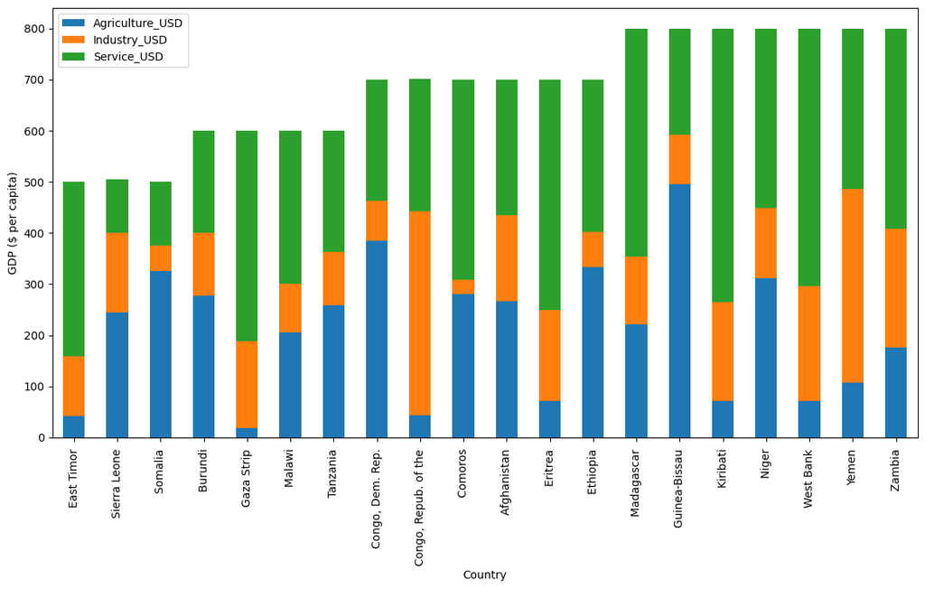

```python
import seaborn as sns
def plot_bar(data1):
    data1['Agriculture_USD'] = data1['Agriculture'] * data1['GDP ($ per capita)']
    data1['Industry_USD'] = data1['Industry'] * data1['GDP ($ per capita)']
    data1['Service_USD'] = data1['Service'] * data1['GDP ($ per capita)']

    data1[['Country', 'Agriculture_USD', 'Industry_USD', 'Service_USD']].set_index('Country').plot.bar(
        stacked=True, figsize=(14,7)
    )
    plt.ylabel('GDP ($ per capita)')
    plt.show()
data_poorest = data_poorest.toPandas()
plot_bar(data_poorest)
```

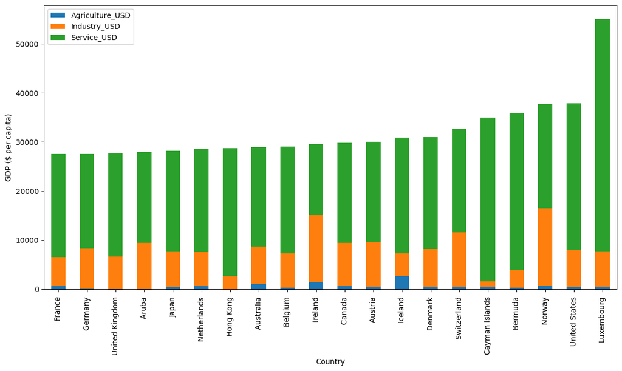

```python
data_richest = data_richest.toPandas()
plot_bar(data_richest)
```

2. Load the dataset “airports.csv” from Kaggle https://www.kaggle.com/jonatancr/airports using the column descriptions from https://openflights.org/data. Plot the locations of selected airports on a map.

```python
from mpl_toolkits.basemap import Basemap
import numpy as np
```

```python
airports = (
    spark.read.csv("file:/home/jovyan/work/Lab2_SQL/airports.csv", inferSchema=True, header=False)
    .toDF("Airport ID", "Name", "City", "Country", "IATA", "ICAO", "Latitude", "Longitude",
          "Altitude", "Timezone", "DST", "Tz database timezone", "Type", "Source")
)
airports.toPandas().head()
```

|  | Airport ID | Name | City | Country | IATA | ICAO | Latitude | Longitude | Altitude | Timezone | DST | Tz database timezone | Type | Source |
| --- | --- | --- | --- | --- | --- | --- | --- | --- | --- | --- | --- | --- | --- | --- |
| 0 | 1 | Goroka Airport | Goroka | Papua New Guinea | GKA | AYGA | -6.081690 | 145.391998 | 5282 | 10 | U | Pacific/Port_Moresby | airport | OurAirports |
| 1 | 2 | Madang Airport | Madang | Papua New Guinea | MAG | AYMD | -5.207080 | 145.789001 | 20 | 10 | U | Pacific/Port_Moresby | airport | OurAirports |
| 2 | 3 | Mount Hagen Kagamuga Airport | Mount Hagen | Papua New Guinea | HGU | AYMH | -5.826790 | 144.296005 | 5388 | 10 | U | Pacific/Port_Moresby | airport | OurAirports |
| 3 | 4 | Nadzab Airport | Nadzab | Papua New Guinea | LAE | AYNZ | -6.569803 | 146.725977 | 239 | 10 | U | Pacific/Port_Moresby | airport | OurAirports |
| 4 | 5 | Port Moresby Jacksons International Airport | Port Moresby | Papua New Guinea | POM | AYPY | -9.443380 | 147.220001 | 146 | 10 | U | Pacific/Port_Moresby | airport | OurAirports |

```python
data2 = airports.select("Latitude","Longitude").toPandas()
lats = data2["Latitude"].tolist()
longs = data2["Longitude"].tolist()
```

Why *toPandas()* before *tolist()*:

https://docs.kanaries.net/topics/PySpark/pyspark-tolist

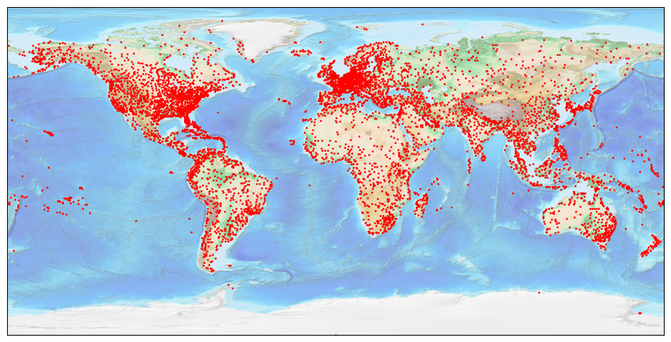

```python
fig = plt.figure(figsize=[12, 6])
m = Basemap(llcrnrlat=-90, urcrnrlat=90,
            llcrnrlon=-180, urcrnrlon=180)
m.etopo(scale=0.5, alpha=0.5)

x_data, y_data = m(longs, lats)

plt.plot(x_data, y_data, 'ro', markersize=1)
plt.show()
```

3. Find the 10 countries where the difference between the highest and lowest airports is the smallest, reporting the results in meters above sea level (m a.s.l.). Include only countries with at least 10 airports.

```python
from pyspark.sql.types import DoubleType
feet_to_m = udf(lambda x: x * 0.3048, DoubleType())
```

```python
from pyspark.sql import functions as F
country_stats = (
    airports
    .groupBy("Country")
    .agg(
        F.count("Name").alias("Airport_Count"),
        F.max("Altitude").alias("Highest_Airport_ft"),
        F.min("Altitude").alias("Lowest_Airport_ft")
    )
    .where(F.col("Airport_Count") >= 10)
    .withColumn("Highest_Airport_m", feet_to_m(F.col("Highest_Airport_ft")))
    .withColumn("Lowest_Airport_m", feet_to_m(F.col("Lowest_Airport_ft")))
    .withColumn("Diff", F.col("Highest_Airport_m") - F.col("Lowest_Airport_m"))
)
data3 = country_stats.orderBy(F.col("Diff")).limit(10)
data3.toPandas()
```

|  | Country | Airport_Count | Highest_Airport_ft | Lowest_Airport_ft | Highest_Airport_m | Lowest_Airport_m | Diff |
| --- | --- | --- | --- | --- | --- | --- | --- |
| 0 | Kiribati | 18 | 10 | 0 | 3.0480 | 0.0000 | 3.0480 |
| 1 | Bahamas | 33 | 26 | 0 | 7.9248 | 0.0000 | 7.9248 |
| 2 | Solomon Islands | 23 | 60 | 0 | 18.2880 | 0.0000 | 18.2880 |
| 3 | Bangladesh | 10 | 125 | 12 | 38.1000 | 3.6576 | 34.4424 |
| 4 | Puerto Rico | 10 | 237 | 9 | 72.2376 | 2.7432 | 69.4944 |
| 5 | Denmark | 27 | 247 | 1 | 75.2856 | 0.3048 | 74.9808 |
| 6 | Panama | 13 | 272 | 10 | 82.9056 | 3.0480 | 79.8576 |
| 7 | New Caledonia | 11 | 315 | 10 | 96.0120 | 3.0480 | 92.9640 |
| 8 | Fiji | 17 | 358 | 0 | 109.1184 | 0.0000 | 109.1184 |
| 9 | Netherlands | 26 | 375 | -15 | 114.3000 | -4.5720 | 118.8720 |

4. Draw a plot showing the relationship between the number of airports and the area of the country.
   - The data for this plot comes from two DataFrames: Countries and Airports, so they need to be joined.
   - Since the country names in both DataFrames may not match exactly, detect which names differ using join mechanisms. Create a DataFrame containing these mismatched names.

Preparation:

```python
df_countries = (
    countries
    .withColumnRenamed("Area (sq. mi.)", "Area")
    .select("Country", "Area")
    .withColumn("Country", F.trim(F.col("Country")))
)

df_airports = (
    airports
    .select("Country")
    .withColumn("Country", F.trim(F.col("Country")))
)

data4 = (
    df_countries
    .join(df_airports, on="Country", how="outer")
)

data4.filter((F.col("Area").isNull()) | (F.col("Country").isNull())).distinct().count()
```

```
32
```

```python
print(df_countries.select("Country").distinct().count())
print(df_airports.select("Country").distinct().count())
```

```
227
237
```

```python
data4.filter((F.col("Area").isNull()) | (F.col("Country").isNull())).distinct().show(300)
```

```
+--------------------+----+
|             Country|Area|
+--------------------+----+
|British Indian Oc...|NULL|
|      Norfolk Island|NULL|
|Northern Mariana ...|NULL|
|Turks and Caicos ...|NULL|
|British Virgin Is...|NULL|
|             Myanmar|NULL|
|             Bahamas|NULL|
|Sao Tome and Prin...|NULL|
|Saint Pierre and ...|NULL|
|    Congo (Kinshasa)|NULL|
|Central African R...|NULL|
|            Svalbard|NULL|
|    Christmas Island|NULL|
|Cocos (Keeling) I...|NULL|
|          Antarctica|NULL|
|Saint Kitts and N...|NULL|
|         North Korea|NULL|
|         South Korea|NULL|
|           Palestine|NULL|
|          Montenegro|NULL|
| Trinidad and Tobago|NULL|
| Congo (Brazzaville)|NULL|
|      Midway Islands|NULL|
|      Johnston Atoll|NULL|
|         South Sudan|NULL|
|              Gambia|NULL|
| Antigua and Barbuda|NULL|
|    Falkland Islands|NULL|
|Bosnia and Herzeg...|NULL|
|         Wake Island|NULL|
|          Micronesia|NULL|
|                Niue|NULL|
+--------------------+----+
```

Exact solution

```python
from pyspark.sql.types import StringType
import re

def fix_country(s):
    s = s.replace(", The", "") \
        .replace("Rep.", "Republic") \
        .replace("Korea, North", "North Korea") \
        .replace("Korea, South", "South Korea") \
        .replace("Is.", "Island") \
        .replace("&", "and") \
        .replace("Burma", "Myanmar")

    s = re.sub("Congo.*", "Congo", s)
    s = re.sub("Micronesia.*", "Micronesia", s)

    return s

fix_country_udf = udf(
    lambda s: fix_country(s),
    StringType()
)
```

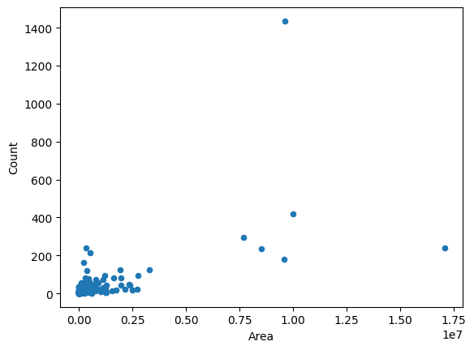

```python
data_countries = (
    countries
    .withColumnRenamed("Area (sq. mi.)", "Area")
    .select("Country", "Area")
    .withColumn("Country", F.trim(F.col("Country")))
    .withColumn("Country", fix_country_udf("Country"))
)

data_airports = (
    airports
    .select("Country")
    .withColumn("Country", F.trim(F.col("Country")))
    .withColumn("Country", fix_country_udf("Country"))
)

countries_airports = (
    data_countries
    .join(data_airports, on="Country", how="left")
    .groupBy("Country", "Area")
    .agg(F.count("Country").alias("Count"))
    .drop("Country")
    .orderBy("Area")
)

countries_airports.toPandas().plot.scatter(
    x="Area",
    y="Count"
)
plt.show()
```

5. Calculate how many airports are in each region. This task also requires joining the Countries and Airports DataFrames. Present the result as a pie chart.

```python
countries.select("Region").distinct().toPandas()
```

|  | Region |
| --- | --- |
| 0 | BALTICS |
| 1 | C.W. OF IND. STATES |
| 2 | ASIA (EX. NEAR EAST) |
| 3 | WESTERN EUROPE |
| 4 | NORTHERN AMERICA |
| 5 | NEAR EAST |
| 6 | EASTERN EUROPE |
| 7 | OCEANIA |
| 8 | SUB-SAHARAN AFRICA |
| 9 | NORTHERN AFRICA |
| 10 | LATIN AMER. & CARIB |

```python
data_countries = (
    countries
    .select("Country", "Region")
    .withColumn("Country", F.trim(F.col("Country")))
    .withColumn("Country", fix_country_udf("Country"))
)

data_airports = (
    airports
    .select("Country")
    .withColumn("Country", F.trim(F.col("Country")))
    .withColumn("Country", fix_country_udf("Country"))
)

df = (
    data_countries
    .join(data_airports, on="Country", how="left")
    .groupBy("Region")
    .agg(F.count("Country").alias("Count"))
)
df = df.toPandas()
```

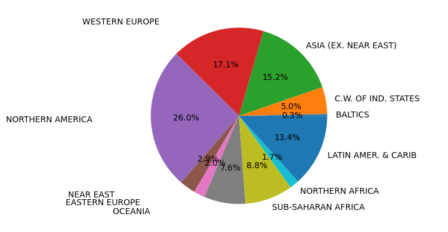

```python
plt.pie(df["Count"], labels=df["Region"], autopct='%1.1f%%')
plt.show()
```